# Preliminary FvFm Analyses

Laura Bogar

2024-10-24

```r
library(tidyverse)
source("read_LI-600.R")

poplar_file_path = "../data/export_2024_10_21_164809/Bogar FvFm/2024-10-15/Bogar FvFm_LMB_2024_10_15_16_28_28_1.csv"
dougfir_file_path = "../data/600N_export/Bogar FvFm 600N/2024-10-15/Bogar FvFm 600N_LMB_2024_10_15_16_24_39_1.csv"
treatments = read_csv("240910_all_plants_and_treatments.csv")
dark_fluor_pop = read_li600_data(poplar_file_path)
```

```
## ──────────────────────────────────────────────────────── Delimiter: "," chr
## (65): Time, Date, configName, configAuthor, remark, Plant number, Leaf ... dbl
## (40): Obs#, Fo, Fm, Fv/Fm, Fs, Fm', PhiPS2, PS2/1, abs, TRANS, type, gs... lgl
## (1): ...9 dttm (1): configUpdatedAt
```

```r
dark_fluor_pop$plantID = dark_fluor_pop$`Plant number`
dark_fluor_doug = read_li600_data(dougfir_file_path)
```

```
## ──────────────────────────────────────────────────────── Delimiter: "," chr
## (65): Time, Date, configName, configAuthor, remark, Plant number, Leaf ... dbl
## (40): Obs#, Fo, Fm, Fv/Fm, Fs, Fm', PhiPS2, PS2/1, abs, TRANS, type, gs... lgl
## (1): ...9 dttm (1): configUpdatedAt
```

```r
dark_fluor_doug$plantID = dark_fluor_doug$`Plant number`

treatments$plantID = str_pad(treatments$Plant, width = 3, pad = "0")
treatments$ABA = fct_recode(treatments$Tape_color,
                            "3 wks" = "O",
                            "2 wks" = "Y",
                            "0 wks" = "G",
                            "None" = "B") %>%
  fct_relevel("0 wks", after = Inf)
treatments$soil = fct_recode(treatments$Soil,
                            "Douglas fir - live" = "DE",
                            "Douglas fir - sterilized" = "DFS",
                            "Poplar - live" = "PE",
                            "Poplar - sterilized" = "PS")

pop_fluor_with_tx = left_join(dark_fluor_pop, treatments)
doug_fluor_with_tx = left_join(dark_fluor_doug, treatments)
# The first few measurements I flagged because we repeated
# them on the two different instruments; may be redundant,
# but these measurements are otherwise valid.
# We should check at some point to make sure
# the 600 and 600N were indeed giving similar values.

pop_fluor_with_tx_noflag = subset(pop_fluor_with_tx, is.na(remark))
doug_fluor_with_tx_noflag = subset(doug_fluor_with_tx, is.na(remark))


pop_fluor_summ = pop_fluor_with_tx_noflag %>% group_by(plantID, Species, soil, ABA) %>%
  summarize(meanfvfm = mean(`Fv/Fm`))
doug_fluor_summ = doug_fluor_with_tx_noflag %>% group_by(plantID, Species, soil, ABA) %>%
  summarize(meanfvfm = mean(`Fv/Fm`))
both_fluor_summ = full_join(pop_fluor_summ, doug_fluor_summ)
both_fluor_summ = both_fluor_summ[!is.na(both_fluor_summ$Species),]
both_fluor_summ = both_fluor_summ[!is.na(both_fluor_summ$ABA),]
```

```r
#I flagged (or meant to flag, did skip a couple) the first 18
# measurements on the Doug firs with the 600N, and it looks
# like the first 15 measurements on the 600. Maybe it doesn't
# matter exactly which got flagged.

tocomp600 = pop_fluor_with_tx[pop_fluor_with_tx$`Plant number` %in% doug_fluor_with_tx$`Plant number`,]
tocomp600N = doug_fluor_with_tx[doug_fluor_with_tx$`Plant number` %in% pop_fluor_with_tx$`Plant number`,]

summ600 = tocomp600 %>% group_by(`Plant number`, configName, Species) %>%
  summarize(meanfvfm = mean(`Fv/Fm`))
summ600N = tocomp600N %>% group_by(`Plant number`, configName, Species) %>%
  summarize(meanfvfm = mean(`Fv/Fm`))
dark_fluor_comparison = full_join(summ600, summ600N)
dark_fluor_comparison$instrument = fct_recode(dark_fluor_comparison$configName, "LI-600" = "Bogar FvFm", "LI-600N" = "Bogar FvFm 600N")
```

Does it matter which instrument we use?

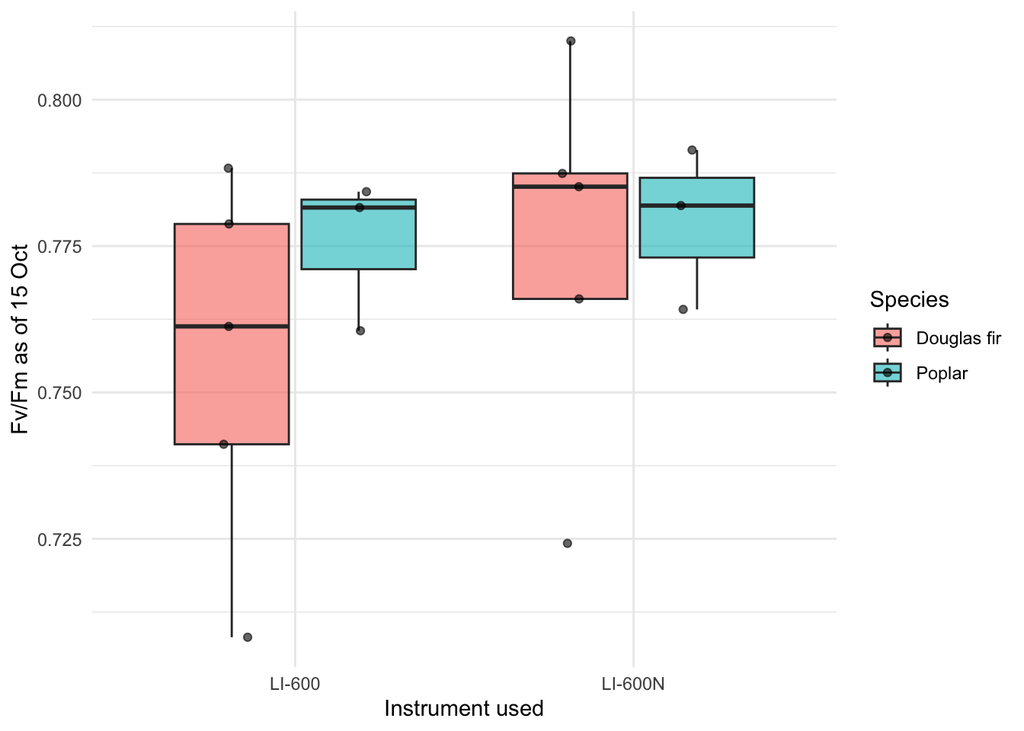

```r
summ600forpaired = summ600 %>% group_by(Species) %>%
  select(`Plant number`, Species, meas600 = meanfvfm)
summ600Nforpaired = summ600N %>% group_by(Species) %>%
  select(everything(), -configName, meas600N = meanfvfm)
paired = left_join(summ600forpaired, summ600Nforpaired)
paired = paired %>% mutate(difference = meas600 - meas600N)

diffbysp = t.test(paired$difference ~ paired$Species)
diffbysp
```

```
##
##  Welch Two Sample t-test
##
## data:  paired$difference by paired$Species
## t = -0.96438, df = 4.1223, p-value = 0.388
## alternative hypothesis: true difference in means between group Douglas fir and group Poplar is not equal to 0
## 95 percent confidence interval:
##  -0.05889829  0.02826696
## sample estimates:
## mean in group Douglas fir      mean in group Poplar
##              -0.019015057              -0.003699389
```

```r
overalldiff = t.test(paired$meas600, paired$meas600N)
overalldiff
```

```
##
##  Welch Two Sample t-test
##
## data:  paired$meas600 and paired$meas600N
## t = -1.0063, df = 13.945, p-value = 0.3314
## alternative hypothesis: true difference in means is not equal to 0
## 95 percent confidence interval:
##  -0.04157010  0.01502674
## sample estimates:
## mean of x mean of y
## 0.7630155 0.7762872
```

[figure not shown]

Conclusion: I think the LI-600 can sometimes underestimate Fv/Fm on the Douglas fir seedlings; perhaps the laser/optics aren’t set up to accommodate masses of needles that have gaps and things in them? The 600 and 600N agreed almost entirely on the poplar leaves, just not on the needles. This difference is not statistically significant with our very small sample size, but it seems big enough that I’m not inclined to use the “wrong” instrument on a needle plant ever again. (600N did fine on poplar, though, and I will happily use it on leaves in the future.)

Mostly, though, I’ve learned that we need to do a more thorough test of this. 3 points for Populus isn’t enough to be sure the 600N is doing a good job. I THINK it is, though.